# MPDW

Hilmi Awfa Abrar

2023-09-04

# Memanggil Library

```r
library("forecast")
```

```r
library("graphics")
library("TTR")
library("TSA")
```

# Import Data

```r
library(readxl)
data <- read_excel("C:/hilmi/ipb/smt 5/MPDW/Praktikum/Data Tugas 1/Data suhu.xlsx",sheet=2)
data
```

| Periode | Suhu |
| --- | --- |
| 1 | 25.05 |
| 2 | 25.28 |
| 3 | 25.22 |
| 4 | 25.69 |
| 5 | 24.99 |
| 6 | 24.95 |
| 7 | 25.12 |
| 8 | 23.65 |
| 9 | 24.18 |
| 10 | 24.12 |

[output cut: 355 more lines]

# Eksplorasi Data

## Melihat data menggunakan fungsi `View()`, struktur data menggunakan fungsi `str()`, dan dimensi data menggunakan fungsi `dim()`.

```r
View(data)
str(data)
```

```
## tibble [365 × 2] (S3: tbl_df/tbl/data.frame)
##  $ Periode: num [1:365] 1 2 3 4 5 6 7 8 9 10 ...
##  $ Suhu   : num [1:365] 25.1 25.3 25.2 25.7 25 ...
```

```r
dim(data)
```

```
## [1] 365   2
```

## Mengubah data agar terbaca sebagai data deret waktu dengan fungsi `ts()` .

```r
data.ts <- ts(data$Suhu)
```

## Menampilkan ringkasan data

```r
summary(data.ts)
```

```
##    Min. 1st Qu.  Median    Mean 3rd Qu.    Max.
##   22.84   24.24   24.73   24.69   25.20   26.22
```

## Membuat plot data deret waktu

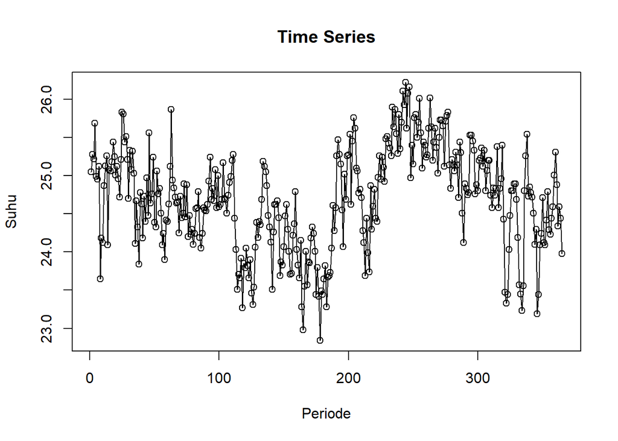

```r
ts.plot(data.ts, xlab="Periode", ylab="Suhu",
        main = "Time Series")
points(data.ts)
```

# Single Avarage Moving (SMA)

Ide dasar dari Single Moving Average (SMA) adalah data suatu periode dipengaruhi oleh data periode sebelumnya. Metode pemulusan ini cocok digunakan untuk pola data stasioner atau konstan. Prinsip dasar metode pemulusan ini adalah data pemulusan pada periode ke-t merupakan rata rata dari m buah data pada periode ke-t hingga periode ke (t-m+1). Data pemulusan pada periode ke-t selanjutnya digunakan sebagai nilai peramalan pada periode ke t+1

## Pembagian data

### Membagi data latih dan data uji

```r
training_ma <- data[1:292,]
testing_ma <- data[293:365,]
train_ma.ts <- ts(training_ma$Suhu)
test_ma.ts <- ts(testing_ma$Suhu)
```

### Eksplorasi data keseluruhan

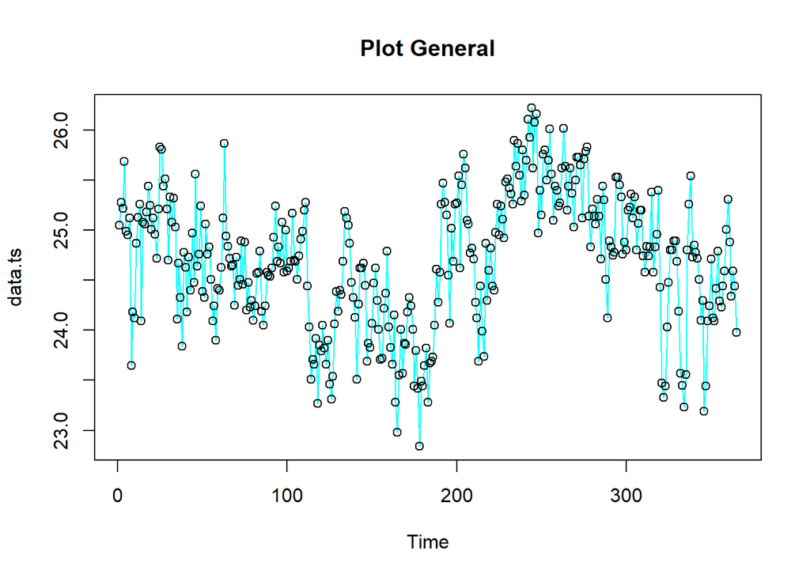

```r
plot(data.ts, col="cyan",main="Plot General")
points(data.ts)
```

### Eksplorasi data latih

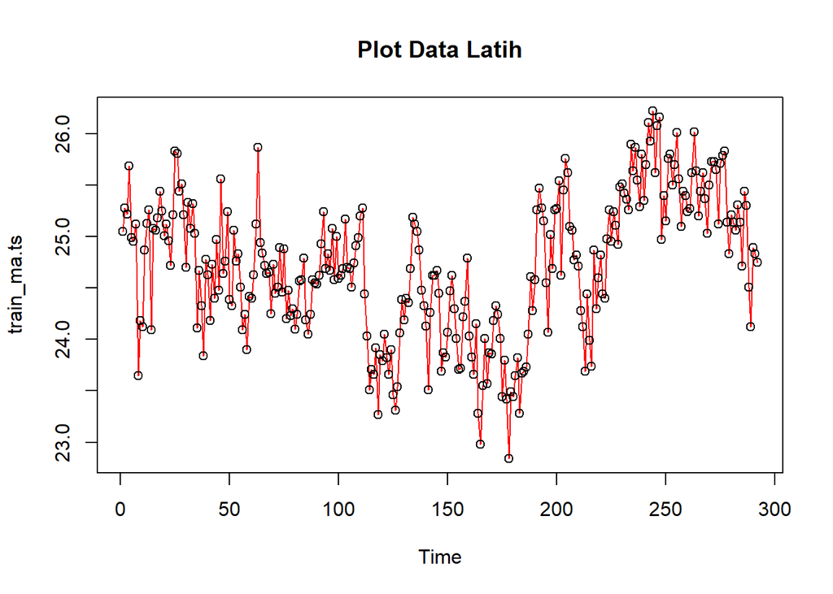

```r
plot(train_ma.ts, col="red",main="Plot Data Latih")
points(train_ma.ts)
```

### Eksplorasi data uji

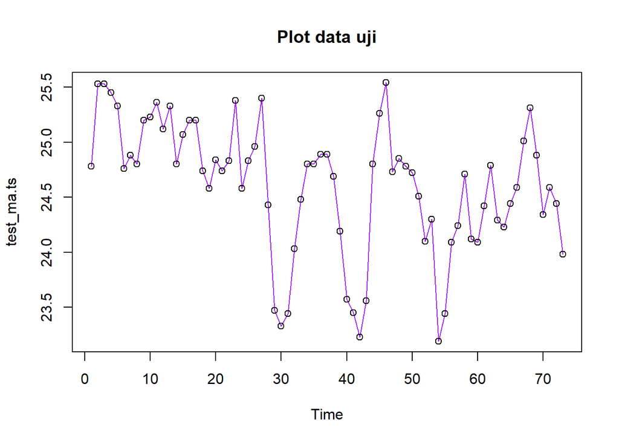

```r
plot(test_ma.ts, col="purple",main="Plot data uji")
points(test_ma.ts)
```